# Differences in Inferences

June 8, 2016

## This talk: code and data

[figure not shown]

**github –> Rmadillo –> SCH_R_Training –> Diff_Inf**

https://github.com/Rmadillo/SCH_R_Training/tree/master/Diff_Inf

https://raw.githubusercontent.com/Rmadillo/SCH_R_Training/master/Diff_Inf/SCEA_presentation_20160608.Rmd

## The study:

Cognitive outcome after focal surgical resection was retrospectively reviewed for 15 cognitively intact children operated on between 2 and 6 years of age for lesion-related, early-onset epilepsy. Wechsler intelligence tests were conducted prior to and after surgery to explore differences in intelligence between short versus long duration of seizures prior to surgical resection.

The paper: Shurtleff et al. 2015. Impact of epilepsy surgery on development of preschool children: identification of a cohort likely to benefit from early intervention. *Journal of Neurosurgery: Pediatrics* 16(4): 383-392. http://dx.doi.org/10.3171/2015.3.PEDS14359

## The practical question:

Does time from Dx to Tx matter for cognitive outcomes?

Literature is mixed, partially due to heterogeneous subjects.

This study focused on a more homogeneous group than seen in other lit.

## The practical question:

Does time from Dx to Tx matter for cognitive outcomes?

*n*=15 patients over a 15 year period.

*n*=11 patients having both pre/post test scores.

## The practical answer:

Does time from Dx to Tx matter for cognitive outcomes?

Probably.

**"…shorter seizure duration prior to resection can result in improved cognitive outcome, suggesting that surgery for this population should occur sooner to help improve intelligence outcomes."**

## Why we concluded this:

Does time from Dx to Tx matter for cognitive outcomes?

"Patients who had surgery within 6 months of onset generally had better outcomes compared with patients who had longer duration from the onset of seizures prior to resection.

While we did not detect statistically significant differences … clinically important improvements for the short duration group occurred in both FSIQ and nonverbal scores; FSIQ and nonverbal scores improved by 13 and 14 points on average, respectively."

## What would *you* do?

[figure not shown]

## R Packages (Ab)Used

```r
require(reshape2)   # manipulate data frames
require(htmlTable)  # txtRound function
require(knitr)      # formatted tables
require(psych)      # summary statistics
require(boot)       # bootstrapping
require(coin)       # permutation tests
require(orddom)     # effect sizes
require(BEST)       # Bayesian analysis
require(AICcmodavg) # IT analysis
require(ggplot2)    # graphing
require(plotly)     # interactive graphing
```

## Summary Stats: Change in FSIQ

**Long (>= 18 months Dx to Tx)**

| vars | n | mean | sd | median | trimmed | mad | min | max | range | se |
| --- | --- | --- | --- | --- | --- | --- | --- | --- | --- | --- |
| 1 | 5 | -1.4 | 11.63185 | -7 | -1.4 | 5.9304 | -11 | 16 | 27 | 5.201923 |

**Short (<= 6 months Dx to Tx)**

| vars | n | mean | sd | median | trimmed | mad | min | max | range | se |
| --- | --- | --- | --- | --- | --- | --- | --- | --- | --- | --- |
| 1 | 6 | 12 | 7.509993 | 10.5 | 12 | 8.8956 | 4 | 22 | 18 | 3.065942 |

## Basic Effect Sizes

**Absolute Mean Difference in FSIQ for Short vs. Long Groups**

|D| = 13

**Percent with Same or Improved FSIQ Score After Surgery**

*Short*: 1.00  
*Long*: 0.40

A mean alone means nothing.

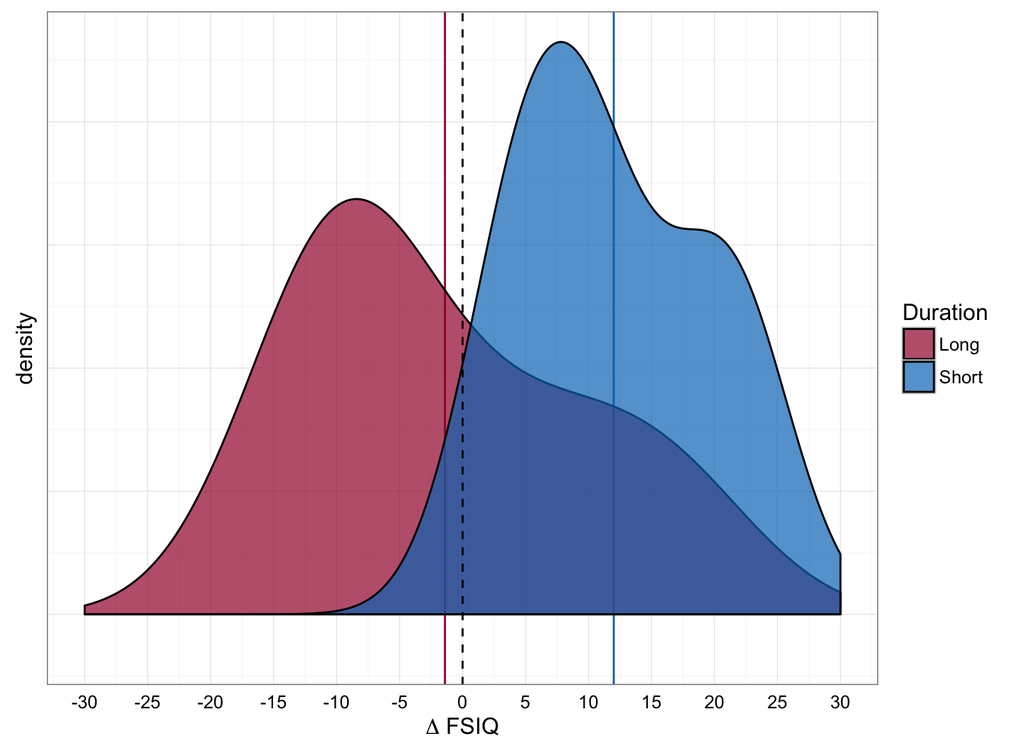

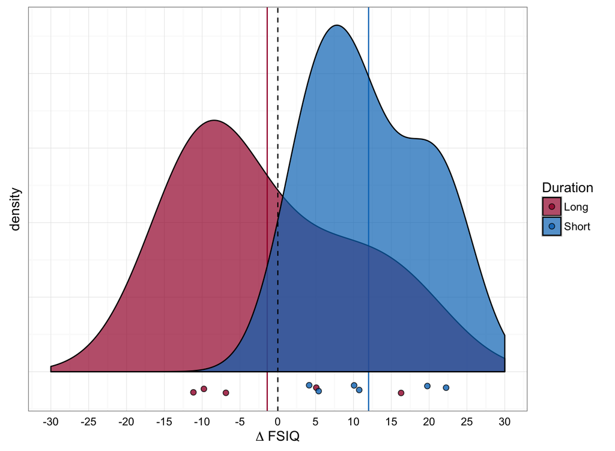

[interactive chart not shown]

[figure not shown]

## *p* > 0.05, therefore maybe we shouldn't accept these results

"**While we did not detect statistically significant differences** …  
clinically important improvements for the short duration group occurred in both FSIQ and nonverbal scores; FSIQ and nonverbal scores improved by 13 and 14 points on average, respectively."

## *p* is controversial

[figure not shown]

## Clinicians don't care…

"For the rest of us, 'what is the p-value?' Is this another urine term?" –an SCH Doctor (personal communication, 2016)

[figure not shown]

## … but we should.

Odds are, it's wrong: Science fails to face the shortcomings of statistics –*Science News* 2010

Significance tests as sorcery: Science is empirical–significance tests are not –*Charles Lambdin, Intel Corporation* 2012

Trouble at the lab: Scientists like to think of science as self-correcting. To an alarming degree, it is not –*The Economist* 2013

The trouble with 'scientific' research today: A lot that's published is junk –*Forbes* 2014

## How best to infer?

- Frequentism
- Effect sizes
- Bayesian
- Information-theory

## How best to infer?

- Frequentism
  - Fisher: *p* is an evidence probability
  - Neyman-Pearson (N-P): α is an error probability
  - NHST: an awkward and incorrect hybrid where you want *p* < α
- Effect sizes
- Bayesian
- Information-theory

## ASA Statement 2016 (Commentaries)

"…p-values calculated from a set of numbers and assuming a statistical model are of limited value and frequently are meaningless… Patients with serious diseases have been harmed." –Donald Berry, biostatistician at MD Anderson Cancer Center

"…people have suffered or died because scientists (and editors, regulators, journalists and others) have used significance tests to interpret results." –Kenneth Rothman, epidemiologist at Boston University

## The humble *t*-test

```r
t.test(DataWideD$FSIQD~DataWideD$Duration, conf.level = 0.9)
```

```
##
##  Welch Two Sample t-test
##
## data:  DataWideD$FSIQD by DataWideD$Duration
## t = -2.2192, df = 6.6224, p-value = 0.06411
## alternative hypothesis: true difference in means is not equal to 0
## 90 percent confidence interval:
##  -24.938771  -1.861229
## sample estimates:
##  mean in group Long mean in group Short
##                -1.4                12.0
```

## Celebrity Smackdown: Fisher vs. N-P

[figure not shown]

vs.

[figure not shown]

## Celebrity Smackdown: Fisher vs. N-P

*Fisher*: *p* is the probability of seeing results equal to or more extreme than your own, **given the truth of the null** (i.e., no effect):

*p* = (data | P[\(H_0\) = 1.0])

*p* is an evidential probability intended to assist one in making a scientific inductive inference based on the results of experimentation.

If the chance of seeing your data **given that in reality there is no effect** is very small, you can *infer* that a more likely explanation of the result is that there *is* an effect.

Said another way, Fisher's "*p* is measure of how embarrassing the data are to the null hypothesis." –*F.E. Harrell* (2007)

## Fisher's PoV

An experiment obtained a low p-value.

- *Assuming* my results are due to chance, my obtained mean difference is very unlikely.
- Therefore, chance may not be the culprit.
- Therefore, I must employ *other methods* to determine what that culprit might be.

## Celebrity Smackdown: Fisher vs. N-P

*Neyman-Pearson*: if probability is long-run frequency, then single events cannot have probabilities. You can only make a decision on how to act, given the outcome. Thus, using *p* as in Fisher's approach is meaningless.

\(\alpha\) is the probability of committing the error of falsely rejecting the null. The only relevant point of *p* is whether it falls below a **pre-determined threshold** (e.g., 0.05, 0.01, etc.).

Thus, a *p* of 0.0001 and a *p* of 0.049 have the same meaning if \(\alpha\) was set *a priori* to 0.05.

## Celebrity Smackdown: Fisher vs. N-P

The interpretation is that *in the long run*, if you pick \(\alpha\) = 0.05 as your threshold, you can expect that only 5 in 100 experiments performed in the same way on the same population would lead you to falsely reject the null.

This is also the basis for the definition of a confidence interval.

[figure not shown]

## N-P argued for a *decision* procedure

[figure not shown]

## Celebrity Smackdown: Fisher vs. N-P

Since Fisher's *p* already assumes the truth of the null, the probability of falsely rejecting the null (i.e., an \(\alpha\) level) is irrelevant…

…so **reporting an exact *p* relative to \(\alpha\) is meaningless.**

## Finally, the actual hypothesis(es)

*Both Fisher and N-P:*

\(H_0\): The true difference between population means is 0.

*N-P only:*

\(H_1\): The true difference between population means is ≠ 0.

## The humble *t*-test's *p*-value

*p* = 0.064

Fisher: "we have weak evidence that our results are different from no effect."

N-P: "the result is not statistically significant; either there is no effect *or* our study did not have the power to detect an effect."

## The humble *t*-test's *p*-value

*p* = 0.064

N-P: "the result is not statistically significant; either there is no effect *or* our study did not have the power to detect an effect."

*Journal 1: "Reject. The power is too low to come to any useful conclusions from this study."*

Fisher: "we have weak evidence that our results are different from no effect."

*Journal 2: "Accept with minor revision. The statistical methods used are appropriate for the small sample size."*

## What would *you* do?

[figure not shown]

## *p*-hacking

**False-Positive Psychology: Undisclosed Flexibility in Data Collection and Analysis Allows Presenting Anything as Significant** [(Simmons et al 2010)](http://opim.wharton.upenn.edu/DPlab/papers/publishedPapers/Simmons_2011_False-Positive%20Psychology.pdf)

"…despite the nominal endorsement of a maximum false-positive rate of 5% (i.e., p ≤ .05), current standards for disclosing details of data collection and analyses make false positives vastly more likely. In fact, it is unacceptably easy to publish 'statistically significant' evidence consistent with *any* hypothesis."

## HOLD THE PRESSES!

(No evidence of unequal variances! More POWER!)

```r
t.test(DataWideD$FSIQD~DataWideD$Duration, var.equal=TRUE,
       conf.level = 0.9)
```

```
##
##  Two Sample t-test
##
## data:  DataWideD$FSIQD by DataWideD$Duration
## t = -2.3139, df = 9, p-value = 0.04595
## alternative hypothesis: true difference in means is not equal to 0
## 90 percent confidence interval:
##  -24.015889  -2.784111
## sample estimates:
##  mean in group Long mean in group Short
##                -1.4                12.0
```

## Frequentist *p*-values

| Test Type | *p*-value |
| --- | --- |
| *t*-test, equal variances | 0.046 |
| *t*-test, unequal variances | 0.064 |
| Permutation test | 0.058 |
| Mann-Whitney-Wilcoxon (asymptotic) | 0.082 |
| Mann-Whitney-Wilcoxon (exact) | 0.093 |
| Linear model (F-test) | 0.046 |

## Adjust for multiple testing?

| Adjustment type | *p*-value |
| --- | --- |
| Holm (conservative) | 0.138 |
| False Discovery Rate (liberal) | 0.075 |

Adjustment based on p-value from *t*-test for equal variances.

Fisher: "what the heck are you even *doing*, you ignorant cretins?"

N-P: "the result is not statistically significant; either there is no effect *or* our study did not have the power to detect an effect. Screw you, Fisher."

## The "New" Statistics: ESSs and CIs

"… rather than reporting isolated *P* values, research articles should focus more on reporting effect sizes (eg, absolute and relative risks) and uncertainty metrics (eg, confidence intervals for the effect estimates)." –*Journal of the American Medical Association* 2016

[figure not shown]

## The "New" Statistics: ESSs and CIs

A thought-example:

| Experiment | Prefer A | Prefer B | Effect size (for A) | *p*-value |
| --- | --- | --- | --- | --- |
| 1 | 15 | 5 | 75% | 0.04 |
| 2 | 114 | 86 | 57% | 0.04 |
| 3 | 1,046 | 954 | 52% | 0.04 |
| 4 | 1,001,455 | 998,555 | 50% | 0.04 |

## The "New" Statistics: ESSs and CIs

A thought-example:

| Experiment | Prefer A | Prefer B | Effect size (for A) | CI |
| --- | --- | --- | --- | --- |
| 1 | 15 | 5 | 75% | (50%, 90%) |
| 2 | 114 | 86 | 57% | (50%, 64%) |
| 3 | 1,046 | 954 | 52% | (50%, 55%) |
| 4 | 1,001,455 | 998,555 | 50% | (50%, 50%) |

## The "New" Statistics: ESSs and CIs

|D| = **13**

| CI Type | 90% confidence interval on \|D\| |
| --- | --- |
| *t*-test, equal variances | 3, 24 |
| *t*-test, unequal variances | 2, 25 |
| Regression | 3, 24 |
| Bootstrapped | 4, 22 |
| Mann-Whitney-Wilcoxon (asymptotic) | 4, 22 |
| Mann-Whitney-Wilcoxon (exact) | 0, 27 |

## The "New" Statistics: ESSs and CIs

|D| = **13**

| CI Type | 90% confidence interval on \|D\| |
| --- | --- |
| Multiple testing adjustment (Bonferroni) | 2, 24 |

## The "New" Statistics: ESSs and CIs

Cohen's *d*: **1.40**

Vargha-Delaney's *A*: **0.82**

| CI Type | 90% confidence interval on ESSs |
| --- | --- |
| Cohen's *d* | 0.09, 2.92 |
| Vargha-Delaney's *A* | 0.45, 0.97 |

## The Bayesian approach

[figure not shown]

## The Bayesian approach

[figure not shown]

## The Bayesian approach

[figure not shown]

## BEST (R + JAGS + rjags et al.)

Kruschke, JK. 2013. Bayesian estimation supersedes the t test. *Journal of Experimental Psychology: General* 142(2): 573-603 [doi: 10.1037/a0029146](http://dx.doi.org/10.1037/a0029146)

Default priors:

[figure not shown]

## The Bayesian approach: BEST results

|  | mean | median | mode | HDI% | HDIlo | HDIup |
| --- | --- | --- | --- | --- | --- | --- |
| mu1 | 11.9 | 11.9 | 11.5 | 90 | 4.7 | 19.4 |
| mu2 | -1.7 | -1.8 | -1.6 | 90 | -15.6 | 12.2 |
| muDiff | 13.6 | 13.6 | 14.3 | 90 | -2.6 | 29.6 |

## The Bayesian approach: BEST results

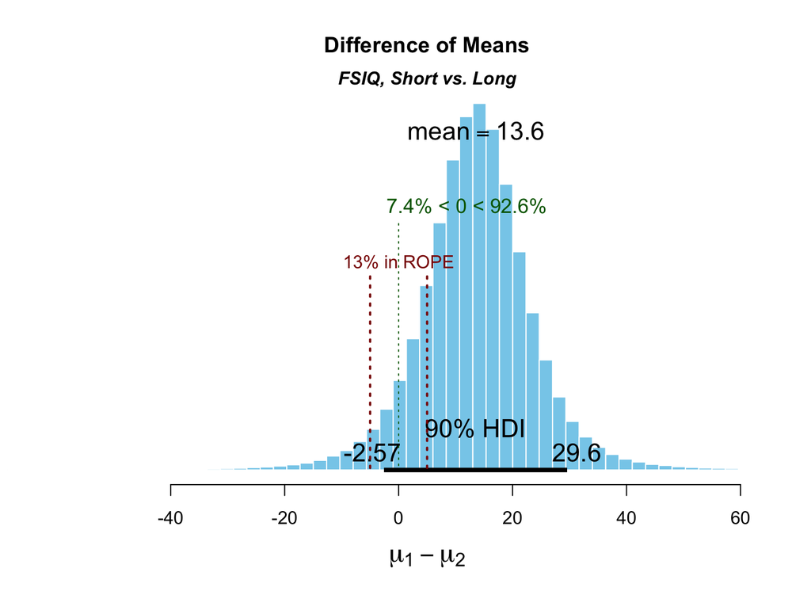

## The Bayesian approach: BEST results

The estimated true mean difference between the two populations is **14**.

The probability that there is any improvement in FSIQ by being in the short duration treatment group is **0.93**.

The probability that there is an improvement of at least 5 points in score by being in the short duration treatment group is **0.84**.

## Information Theory

[figure not shown]

## Information Theory

[figure not shown]

## Information Theory: the model set

**\(H_1\):**  
Δ FSIQ = \(\beta_0\) + *Tx Group* + \(\epsilon\)

Δ FSIQ = -1.40 + 13.40

**\(H_0\):**  
Δ FSIQ = \(\beta_0\) + \(\epsilon\)

Δ FSIQ = 5.91

## AIC Table for FSIQ

| Modnames | K | AICc | Delta_AICc | ModelLik | AICcWt | LL | Cum.Wt |
| --- | --- | --- | --- | --- | --- | --- | --- |
| H1 | 3 | 88.11 | 0.00 | 1.00 | 0.65 | -39.34 | 0.65 |
| H0 | 2 | 89.32 | 1.21 | 0.55 | 0.35 | -41.91 | 1.00 |

\(H_1\) is 1.8 times more likely than \(H_0\)

## IT methods allow for model averaging

**\(\beta_0\)**

```
##
## Multimodel inference on "(Intercept)" based on AICc
##
## AICc table used to obtain model-averaged estimate:
##
##    K  AICc Delta_AICc AICcWt Estimate   SE
## H1 3 88.11       0.00   0.65    -1.40 4.28
## H0 2 89.32       1.21   0.35     5.91 3.45
##
## Model-averaged estimate: 1.18
## Unconditional SE: 5.32
## 90% Unconditional confidence interval: -7.56, 9.93
```

## IT methods allow for model averaging

**\(\beta_1\)**

```
##
## Multimodel inference on "DataWideD$DurationShort" based on AICc
##
## AICc table used to obtain model-averaged estimate:
##
##    K  AICc Delta_AICc AICcWt Estimate   SE
## H1 3 88.11          0      1     13.4 5.79
##
## Model-averaged estimate: 13.4
## Unconditional SE: 5.79
## 90% Unconditional confidence interval: 3.87, 22.93
```

## IT methods allow for model averaging

**Model averaged effect size for FSIQ model set**

```
##
## Model-averaged effect size on the response scale based on entire model set:
##
##
## Multimodel inference on "DataWideD.DurationShort - DataWideD.DurationLong" based on AICc
##
## AICc table used to obtain model-averaged effect size:
##
##    K  AICc Delta_AICc AICcWt Effect(Short - Long)   SE
## H1 3 88.11       0.00   0.65                 13.4 5.79
## H0 2 89.32       1.21   0.35                  0.0 4.89
##
## Model-averaged effect size: 8.66
## Unconditional SE: 8.44
## 90% Unconditional confidence interval: -5.21, 22.54
```

## Hypothesized model outcome

Accounting for model uncertainty, the likely effect size of being in the short duration treatment group is **9** FSIQ points (90% CI: -5, 23).

[figure not shown]

## How best to infer?

- Frequentism
  - Fisher: *p* is an evidence probability
  - Neyman-Pearson (N-P): α is an error probability
  - NHST*: an awkward and incorrect hybrid where you want *p* < α
- Effect sizes
- Bayesian
- Information-theory

* A good way to remember this hybrid's inferential power is by thinking of it as **S**tatistical **H**ypothesis **I**nference **T**esting.

## How best to infer?

- Frequentism
  - Fisher: *p* is an evidence probability
  - Neyman-Pearson (N-P): α is an error probability
  - NHST*: an awkward and incorrect hybrid where you want *p* < α
- Effect sizes
- Bayesian
- Information-theory

* A good way to remember this hybrid's inferential power is by thinking of it as **S**tatistical **H**ypothesis **I**nference **T**esting.

## How best to infer?

"As in any branch of science, new and improved statistical methods are constantly being developed. Ecologists would not use 80-year-old genetic or physiological techniques when more powerful and useful methods are available. Why don't we apply the same standards when drawing conclusions from our data?" –[Gerrodette 2011](https://swfsc.noaa.gov/uploadedfiles/divisions/prd/programs/etp_cetacean_assessment/gerrodette2011inferencewithoutsignificance.pdf)

(Defending *p*-values as the primary inferential method is akin to defending Punnett squares as the best tool for modern genetics.)

## How best to infer?

There are three different general questions one can ask given a data set [(Royall 1997](http://www.amazon.com/Statistical-Evidence-Likelihood-Monographs-Probability/dp/0412044110), [Dienes 2008)](http://www.amazon.com/Understanding-Psychology-Science-Introduction-Statistical/dp/023054231X):

1. What should I do?
2. What should I believe?
3. How should I treat the data as evidence for one theory rather than another?

These are different.

## How best to infer? Statistical pragmatism

There are three different general questions one can ask given a data set [(Royall 1997](http://www.amazon.com/Statistical-Evidence-Likelihood-Monographs-Probability/dp/0412044110), [Dienes 2008)](http://www.amazon.com/Understanding-Psychology-Science-Introduction-Statistical/dp/023054231X):

1. What should I do? **Use Neyman-Pearson frequentist tools**
2. What should I believe? **Use Bayesian tools**
3. How should I treat the data as evidence for one theory rather than another? **Use information-theoretic tools**

## How best to infer? Statistical pragmatism

"Experimental" conditions ([Ellison et al. 2014](http://dx.doi.org/10.1890/13-1911.1)):

| Example Conditions | Suggested Paradigm |
| --- | --- |
| • Processes giving rise to observed data are complex and poorly understood • Replicated experiments would be difficult or impossible to devise | Information-theoretic |
| • Relatively simple processes give rise to observed data • Replicated experiments are possible • Prior understanding or knowledge exists | N-P or Bayesian |

## How best to infer? Statistical pragmatism

1. **Use Neyman-Pearson frequentist tools** (properly) to obtain decision procedures with good long-term error probabilities.
2. **Use Bayesian tools** if you need to know what you should believe.
3. **Use information-theoretic tools** if you need to know what the evidence is.

[(Dienes 2008)](http://www.amazon.com/Understanding-Psychology-Science-Introduction-Statistical/dp/023054231X)

## How best to infer?

- Frequentism
  - Fisher: *p* is an evidence probability
  - Neyman-Pearson (N-P): α is an error probability
  - NHST: an awkward and incorrect hybrid where you want *p* < α
- Effect sizes
- Bayesian
- Information-theory

## The impact of statistical philosophy on brain surgery:

- **Frequentism:** the result was (was not?) statistically significant (*p* = 0.06)
- **Effect sizes:** |D| = 13 (90% CI: 3, 24); *d* = 1.4 (90% CI: 0.1, 2.9); *A* = 0.82 (90% CI: 0.45, 0.97)
- **Bayesian:** posterior |D| = 14 (90% HDI: -2, 30), 92% chance of being > 0, 83% chance of being > 5
- **Information-theory:** evidence in data suggests that |D| = 9 (90% CI: -5, 23); 35% chance \(H_0\) is best model; \(H_1\) is 1.8x more likely than \(H_0\)

## What would *you* do?

[figure not shown]

**Science Isn’t Broken. It’s just a hell of a lot harder than we give it credit for.** [(Aschwanden 2015)](http://fivethirtyeight.com/features/science-isnt-broken/#part1)